# 2022 aasta sõidukite CO2 heite analüüs

Projekt õppeaines RAM0580 Andmeanalüüs

Koostajad: Maksim Ljubimov, Maksim Lupanov, Pavel Sarapov, Samuil Batsinski

Esitatud: 27.05.2026

# 1 Sissejuhatus

## 1.1 Andmestiku kirjeldus

Selles projektis kasutame andmestikku **FuelConsumption.csv**, mis pärineb Kanada Loodusvarade Ameti (Natural Resources Canada) 2022. aasta sõidukite kütusekulu reitingute andmebaasist.

**Allikas:** Natural Resources Canada, *2022 Fuel Consumption Ratings*

**Mõõtmisaeg:** 2022. aasta mudeliaasta sõidukid, andmed kogutud enne müügile jõudmist.

**Tunnused:**

| Tunnus | Kirjeldus | Tüüp |
| --- | --- | --- |
| make | Tootja | Kategooriline |
| model | Mudel | Kategooriline |
| vehicle_class | Sõidukiklass | Kategooriline |
| engine_size_l | Mootori maht (liitrites) | Arvuline |
| cylinders | Silindrite arv | Arvuline |
| transmission | Käigukast (kood: tüüp + käikude arv, nt M6 = käsikäigukast 6 käiguga) | Kategooriline |
| fuel_type | Kütusetüüp (D = diisel, E = etanool E85, X = tavaline bensiin, Z = premium bensiin) | Kategooriline |
| fuel_consumption_city_l_100_km | Kütusekulu linnas (L/100 km) | Arvuline |
| fuel_consumption_hwy_l_100_km | Kütusekulu maanteel (L/100 km) | Arvuline |
| fuel_consumption_comb_l_100_km | Kombineeritud kütusekulu (L/100 km) - põhiühik | Arvuline |
| fuel_consumption_comb_mpg | Kombineeritud kütusekulu (mpg, lisainfo) | Arvuline |
| **co2_emissions_g_km** | **CO2 heide (g/km) - sihttunnus Y** | Arvuline |
| co2_rating | CO2 reiting (1-10, kus 10 = kõige väiksem heide) | Arvuline |
| smog_rating | Sudu reiting (1-10, kus 10 = kõige puhtam) | Arvuline |

**Käigukasti tüüpide selgitus:**

| Kood | Tüüp |
| --- | --- |
| A | Automaatkäigukast |
| AM | Robotiseeritud käsikäigukast |
| AS | Automaatkäigukast käsijuhtimisega |
| AV | Pidevalt muutuva ülekandega käigukast (CVT) |
| M | Käsikäigukast |

Arv koodi järel näitab käikude arvu (nt A8 = automaatkäigukast 8 käiguga; AV-l käike ei ole).

```r
library(tidyverse)
library(janitor)
library(skimr)
library(DT)

raw <- read.csv("SAMPLE/FuelConsumption.csv", check.names = FALSE)
df  <- clean_names(raw)

cat("Objektide arv:", nrow(df), "\n")
```

```
## Objektide arv: 946
```

```r
cat("Tunnuste arv:",  ncol(df), "\n")
```

```
## Tunnuste arv: 15
```

Andmestikus on **946 objekti** (sõidukit) ja **15 tunnust**.

## 1.2 Uurimiseesmärk

Eesmärk on uurida, millised sõiduki omadused mõjutavad CO2 heidet (g/km) 2022. aasta Kanada turul müüdavate sõidukite puhul. Sihttunnuseks on valitud **co2_emissions_g_km**, mis näitab, kui palju CO2 sõiduk kilomeetri kohta õhku heidab. Kütusekulu mõõdetakse ühikus liitrit 100 km kohta (L/100 km). Andmestikus on ka mpg (miles per gallon), mis on Ameerika mõõtühik ja näitab sama asja vastupidises suunas - seda kasutame ainult lisainfona.

## 1.3 Tööhüpoteesid (tööülesanded)

Iga rühmaliige vastutab ühe hüpoteesi eest:

| # | Hüpotees | Meetod | Vastutaja |
| --- | --- | --- | --- |
| H1 | CO2 heide erineb statistiliselt oluliselt erinevate sõidukiklasside vahel | ANOVA | Maksim Ljubimov |
| H2 | Premium bensiini (Z) ja tavalise bensiini (X) kasutajate CO2 heite keskväärtused on erinevad | t-test | Pavel Sarapov |
| H3 | CO2 heidet on võimalik ennustada mootori mahu ja silindrite arvu põhjal | Regressioonanalüüs | Maksim Lupanov |
| H4 | Kütusetüüp ja sõidukiklass ei ole teineteisest sõltumatud | Hii-ruut test | Samuil Batsinski |

## 1.4 Uuringu käik

Analüüs koosneb neljast osast:

1. **Andmete ettevalmistamine** - andmestiku laadimine, korrastamine, duplikaatide ja puuduvate väärtuste eemaldamine.
2. **Esmaanalüüs** - tunnuste jaotuste kirjeldamine graafikute ja arvkarakteristikutega; sihttunnuse Y eraldi vaatlus.
3. **Seoste analüüs** - sihttunnuse Y seos teiste tunnustega.
4. **Hüpoteeside kontrollimine** - iga rühmaliige kontrollib oma hüpoteesi valitud meetodiga, olulisuse nivool α = 0,05.

Kasutatud tarkvara: **R** koos pakettidega `tidyverse`, `janitor`, `skimr`, `DT`, `ggplot2`.

# 2 Andmete ettevalmistamine

## 2.1 Andmete laadimine

Andmestik laaditakse CSV-failist. Allolev tabel võimaldab andmeid sirvida.

```r
datatable(
  df,
  options = list(scrollX = TRUE, pageLength = 10, searching = FALSE,
                 scroller = TRUE, scrollY = 300)
)
```

|  | model_year | make | model | vehicle_class | engine_size_l | cylinders | transmission | fuel_type | fuel_consumption_city_l_100_km | fuel_consumption_hwy_l_100_km | fuel_consumption_comb_l_100_km | fuel_consumption_comb_mpg | co2_emissions_g_km | co2_rating | smog_rating |
| --- | --- | --- | --- | --- | --- | --- | --- | --- | --- | --- | --- | --- | --- | --- | --- |
| 1 | 2022 | Acura | ILX | Compact | 2.4 | 4 | AM8 | Z | 9.9 | 7 | 8.6 | 33 | 200 | 6 | 3 |
| 2 | 2022 | Acura | MDX SH-AWD | SUV: Small | 3.5 | 6 | AS10 | Z | 12.6 | 9.4 | 11.2 | 25 | 263 | 4 | 5 |
| 3 | 2022 | Acura | RDX SH-AWD | SUV: Small | 2 | 4 | AS10 | Z | 11 | 8.6 | 9.9 | 29 | 232 | 5 | 6 |
| 4 | 2022 | Acura | RDX SH-AWD A-SPEC | SUV: Small | 2 | 4 | AS10 | Z | 11.3 | 9.1 | 10.3 | 27 | 242 | 5 | 6 |
| 5 | 2022 | Acura | TLX SH-AWD | Compact | 2 | 4 | AS10 | Z | 11.2 | 8 | 9.8 | 29 | 230 | 5 | 7 |
| 6 | 2022 | Acura | TLX SH-AWD A-SPEC | Compact | 2 | 4 | AS10 | Z | 11.3 | 8.1 | 9.8 | 29 | 231 | 5 | 7 |
| 7 | 2022 | Acura | TLX Type S | Compact | 3 | 6 | AS10 | Z | 12.3 | 9.4 | 11 | 26 | 256 | 5 | 5 |
| 8 | 2022 | Acura | TLX Type S (Performance Tire) | Compact | 3 | 6 | AS10 | Z | 12.3 | 9.8 | 11.2 | 25 | 261 | 4 | 5 |
| 9 | 2022 | Alfa Romeo | Giulia | Mid-size | 2 | 4 | A8 | Z | 10 | 7.2 | 8.7 | 32 | 205 | 6 | 3 |
| 10 | 2022 | Alfa Romeo | Giulia AWD | Mid-size | 2 | 4 | A8 | Z | 10.5 | 7.7 | 9.2 | 31 | 217 | 5 | 3 |

[output cut: 936 more lines]

## 2.2 Andmestiku ülevaade

`str()` näitab andmestiku struktuuri: ridade ja veergude arv ning iga tunnuse tüüp.

```r
str(df)
```

```
## 'data.frame':    946 obs. of  15 variables:
##  $ model_year                    : int  2022 2022 2022 2022 2022 2022 2022 2022 2022 2022 ...
##  $ make                          : chr  "Acura" "Acura" "Acura" "Acura" ...
##  $ model                         : chr  "ILX" "MDX SH-AWD" "RDX SH-AWD" "RDX SH-AWD A-SPEC" ...
##  $ vehicle_class                 : chr  "Compact" "SUV: Small" "SUV: Small" "SUV: Small" ...
##  $ engine_size_l                 : num  2.4 3.5 2 2 2 2 3 3 2 2 ...
##  $ cylinders                     : int  4 6 4 4 4 4 6 6 4 4 ...
##  $ transmission                  : chr  "AM8" "AS10" "AS10" "AS10" ...
##  $ fuel_type                     : chr  "Z" "Z" "Z" "Z" ...
##  $ fuel_consumption_city_l_100_km: num  9.9 12.6 11 11.3 11.2 11.3 12.3 12.3 10 10.5 ...
##  $ fuel_consumption_hwy_l_100_km : num  7 9.4 8.6 9.1 8 8.1 9.4 9.8 7.2 7.7 ...
##  $ fuel_consumption_comb_l_100_km: num  8.6 11.2 9.9 10.3 9.8 9.8 11 11.2 8.7 9.2 ...
##  $ fuel_consumption_comb_mpg     : int  33 25 29 27 29 29 26 25 32 31 ...
##  $ co2_emissions_g_km            : int  200 263 232 242 230 231 256 261 205 217 ...
##  $ co2_rating                    : int  6 4 5 5 5 5 5 4 6 5 ...
##  $ smog_rating                   : int  3 5 6 6 7 7 5 5 3 3 ...
```

```r
n_obj <- nrow(df)
n_var <- ncol(df)
n_obj; n_var
```

```
## [1] 946
```

```
## [1] 15
```

Andmestikus on **946 objekti** ja **15 tunnust**.

`skim()` annab täpsema kokkuvõtte: arvuliste tunnuste puhul näitab keskväärtust, standardhälvet ja kvartiilid; kategooriliste puhul unikaalsete väärtuste arvu.

```r
skim(df)
```

Data summary

| Name | df |
| --- | --- |
| Number of rows | 946 |
| Number of columns | 15 |
| _______________________ |  |
| Column type frequency: |  |
| character | 5 |
| numeric | 10 |
| ________________________ |  |
| Group variables | None |

**Variable type: character**

| skim_variable | n_missing | complete_rate | min | max | empty | n_unique | whitespace |
| --- | --- | --- | --- | --- | --- | --- | --- |
| make | 0 | 1 | 3 | 13 | 0 | 39 | 0 |
| model | 0 | 1 | 2 | 46 | 0 | 715 | 0 |
| vehicle_class | 0 | 1 | 7 | 23 | 0 | 14 | 0 |
| transmission | 0 | 1 | 2 | 4 | 0 | 23 | 0 |
| fuel_type | 0 | 1 | 1 | 1 | 0 | 4 | 0 |

**Variable type: numeric**

| skim_variable | n_missing | complete_rate | mean | sd | p0 | p25 | p50 | p75 | p100 | hist |
| --- | --- | --- | --- | --- | --- | --- | --- | --- | --- | --- |
| model_year | 0 | 1 | 2022.00 | 0.00 | 2022.0 | 2022.00 | 2022.0 | 2022.00 | 2022.0 | ▁▁▇▁▁ |
| engine_size_l | 0 | 1 | 3.20 | 1.37 | 1.2 | 2.00 | 3.0 | 3.80 | 8.0 | ▇▆▂▂▁ |
| cylinders | 0 | 1 | 5.67 | 1.93 | 3.0 | 4.00 | 6.0 | 6.00 | 16.0 | ▇▇▁▁▁ |
| fuel_consumption_city_l_100_km | 0 | 1 | 12.51 | 3.45 | 4.0 | 10.20 | 12.2 | 14.70 | 30.3 | ▂▇▃▁▁ |
| fuel_consumption_hwy_l_100_km | 0 | 1 | 9.36 | 2.29 | 3.9 | 7.70 | 9.2 | 10.70 | 20.9 | ▂▇▃▁▁ |
| fuel_consumption_comb_l_100_km | 0 | 1 | 11.09 | 2.88 | 4.0 | 9.10 | 10.8 | 12.90 | 26.1 | ▂▇▃▁▁ |
| fuel_consumption_comb_mpg | 0 | 1 | 27.25 | 7.69 | 11.0 | 22.00 | 26.0 | 31.00 | 71.0 | ▅▇▂▁▁ |
| co2_emissions_g_km | 0 | 1 | 259.17 | 64.44 | 94.0 | 213.25 | 257.0 | 300.75 | 608.0 | ▂▇▃▁▁ |
| co2_rating | 0 | 1 | 4.54 | 1.47 | 1.0 | 3.00 | 5.0 | 5.00 | 10.0 | ▁▇▇▂▁ |
| smog_rating | 0 | 1 | 4.95 | 1.68 | 1.0 | 3.00 | 5.0 | 6.00 | 7.0 | ▁▅▁▆▇ |

```r
is_num <- sapply(df, is.numeric)
cat("Arvulised tunnused:", sum(is_num), "\n")
```

```
## Arvulised tunnused: 10
```

```r
cat("Mittearvulised tunnused:", sum(!is_num), "\n\n")
```

```
## Mittearvulised tunnused: 5
```

```r
cat("Arvulised:", paste(names(df)[is_num],  collapse = ", "), "\n")
```

```
## Arvulised: model_year, engine_size_l, cylinders, fuel_consumption_city_l_100_km, fuel_consumption_hwy_l_100_km, fuel_consumption_comb_l_100_km, fuel_consumption_comb_mpg, co2_emissions_g_km, co2_rating, smog_rating
```

```r
cat("Mittearvulised:", paste(names(df)[!is_num], collapse = ", "), "\n")
```

```
## Mittearvulised: make, model, vehicle_class, transmission, fuel_type
```

## 2.3 Duplikaatide kontroll

Duplikaadid on read, kus kõik väärtused korduvad täpselt - sama sõiduk on sisestatud mitu korda. Need eemaldatakse.

```r
cat("Duplikaatide arv enne puhastamist:", sum(duplicated(df)), "\n")
```

```
## Duplikaatide arv enne puhastamist: 0
```

```r
df <- df[!duplicated(df), ]
cat("Duplikaatide arv pärast puhastamist:", sum(duplicated(df)), "\n")
```

```
## Duplikaatide arv pärast puhastamist: 0
```

## 2.4 Puuduvate väärtuste kontroll

Puuduvad väärtused (NA) on lahtrid, kus andmed puuduvad. Statistilised funktsioonid ei tule NA-dega hästi toime, seega kontrollime nende olemasolu.

```r
cat("NA-de koguarv:", sum(is.na(df)), "\n")
```

```
## NA-de koguarv: 0
```

```r
cat("Ridade arv vähemalt ühe NA-ga:", sum(!complete.cases(df)), "\n")
```

```
## Ridade arv vähemalt ühe NA-ga: 0
```

```r
colSums(is.na(df))
```

```
##                     model_year                           make
##                              0                              0
##                          model                  vehicle_class
##                              0                              0
##                  engine_size_l                      cylinders
##                              0                              0
##                   transmission                      fuel_type
##                              0                              0
## fuel_consumption_city_l_100_km  fuel_consumption_hwy_l_100_km
##                              0                              0
## fuel_consumption_comb_l_100_km      fuel_consumption_comb_mpg
##                              0                              0
##             co2_emissions_g_km                     co2_rating
##                              0                              0
##                    smog_rating
##                              0
```

Teksttunnustes kontrollime ka tühje lahtreid, mis ei ole NA, aga tähendavad samuti puuduvat väärtust. Need asendatakse väärtusega `Unknown`.

```r
df <- df %>%
  mutate(across(where(is.character), ~na_if(trimws(.x), ""))) %>%
  mutate(across(where(is.character), ~replace_na(.x, "Unknown")))
```

## 2.5 Faktortunnuste moodustamine

Tekstina loetud kategoorilised tunnused teisendatakse faktoriteks. Faktor on R-is kategooriliste andmete tüüp, mida on vaja statistiliste testide (ANOVA, hii-ruut) ja graafikute jaoks.

```r
df <- df %>% mutate(across(where(is.character), as.factor))
skim(df)
```

Data summary

| Name | df |
| --- | --- |
| Number of rows | 946 |
| Number of columns | 15 |
| _______________________ |  |
| Column type frequency: |  |
| factor | 5 |
| numeric | 10 |
| ________________________ |  |
| Group variables | None |

**Variable type: factor**

| skim_variable | n_missing | complete_rate | ordered | n_unique | top_counts |
| --- | --- | --- | --- | --- | --- |
| make | 0 | 1 | FALSE | 39 | For: 89, Che: 80, Por: 77, BMW: 60 |
| model | 0 | 1 | FALSE | 715 | Mus: 5, Sie: 5, Sie: 5, Sil: 5 |
| vehicle_class | 0 | 1 | FALSE | 14 | SUV: 197, SUV: 141, Mid: 117, Pic: 113 |
| transmission | 0 | 1 | FALSE | 23 | AS8: 212, A8: 100, AS1: 87, A10: 72 |
| fuel_type | 0 | 1 | FALSE | 4 | Z: 458, X: 446, D: 28, E: 14 |

**Variable type: numeric**

| skim_variable | n_missing | complete_rate | mean | sd | p0 | p25 | p50 | p75 | p100 | hist |
| --- | --- | --- | --- | --- | --- | --- | --- | --- | --- | --- |
| model_year | 0 | 1 | 2022.00 | 0.00 | 2022.0 | 2022.00 | 2022.0 | 2022.00 | 2022.0 | ▁▁▇▁▁ |
| engine_size_l | 0 | 1 | 3.20 | 1.37 | 1.2 | 2.00 | 3.0 | 3.80 | 8.0 | ▇▆▂▂▁ |
| cylinders | 0 | 1 | 5.67 | 1.93 | 3.0 | 4.00 | 6.0 | 6.00 | 16.0 | ▇▇▁▁▁ |
| fuel_consumption_city_l_100_km | 0 | 1 | 12.51 | 3.45 | 4.0 | 10.20 | 12.2 | 14.70 | 30.3 | ▂▇▃▁▁ |
| fuel_consumption_hwy_l_100_km | 0 | 1 | 9.36 | 2.29 | 3.9 | 7.70 | 9.2 | 10.70 | 20.9 | ▂▇▃▁▁ |
| fuel_consumption_comb_l_100_km | 0 | 1 | 11.09 | 2.88 | 4.0 | 9.10 | 10.8 | 12.90 | 26.1 | ▂▇▃▁▁ |
| fuel_consumption_comb_mpg | 0 | 1 | 27.25 | 7.69 | 11.0 | 22.00 | 26.0 | 31.00 | 71.0 | ▅▇▂▁▁ |
| co2_emissions_g_km | 0 | 1 | 259.17 | 64.44 | 94.0 | 213.25 | 257.0 | 300.75 | 608.0 | ▂▇▃▁▁ |
| co2_rating | 0 | 1 | 4.54 | 1.47 | 1.0 | 3.00 | 5.0 | 5.00 | 10.0 | ▁▇▇▂▁ |
| smog_rating | 0 | 1 | 4.95 | 1.68 | 1.0 | 3.00 | 5.0 | 6.00 | 7.0 | ▁▅▁▆▇ |

## 2.6 Grupimahtude kontroll

Enne analüüsi kontrollime, mitu vaatlust iga kategoorilise tunnuse igas rühmas on. Väga väikese valimiga rühmade tulemused on ebausaldusväärsed.

```r
cat("=== Tootja (make) - vaatluste arv ===\n")
```

```
## === Tootja (make) - vaatluste arv ===
```

```r
sort(table(df$make))
```

```
##
##          FIAT       Bugatti  Aston Martin    Alfa Romeo      Chrysler
##             1             3             5             6             6
##       Lincoln    Mitsubishi   Rolls-Royce         Acura       Bentley
##             7             7             7             8             8
##       Genesis      Infiniti        Jaguar   Lamborghini         Buick
##             8             8             8             8             9
##         Volvo      Maserati           Ram    Land Rover    Volkswagen
##            12            13            16            18            18
##        Subaru          MINI         Dodge         Honda         Mazda
##            19            20            21            23            23
##        Nissan           Kia      Cadillac         Lexus       Hyundai
##            23            25            26            28            29
##          Jeep Mercedes-Benz          Audi        Toyota           GMC
##            34            43            45            51            54
##           BMW       Porsche     Chevrolet          Ford
##            60            77            80            89
```

Tootjatest on **FIAT** esindatud vaid 1 sõidukiga ja **Bugatti** 3 sõidukiga - neid ei saa eraldi statistilises analüüsis kasutada, kuna valim on liiga väike. Kui analüüsis kasutatakse tootjaid, rakendatakse filtrit n >= 5.

```r
cat("=== Sõidukiklass (vehicle_class) - vaatluste arv ===\n")
```

```
## === Sõidukiklass (vehicle_class) - vaatluste arv ===
```

```r
sort(table(df$vehicle_class))
```

```
##
##                 Minivan Station wagon: Mid-size Special purpose vehicle
##                       7                       8                      12
##    Station wagon: Small     Pickup truck: Small             Minicompact
##                      19                      20                      48
##              Two-seater               Full-size                 Compact
##                      51                      64                      69
##              Subcompact  Pickup truck: Standard                Mid-size
##                      80                     113                     117
##           SUV: Standard              SUV: Small
##                     141                     197
```

```r
cat("\n=== Kütusetüüp (fuel_type) - vaatluste arv ===\n")
```

```
##
## === Kütusetüüp (fuel_type) - vaatluste arv ===
```

```r
sort(table(df$fuel_type))
```

```
##
##   E   D   X   Z
##  14  28 446 458
```

Sõidukiklassidest on **Minivan** (n=7) ja **Station wagon: Mid-size** (n=8) väikese valimiga - ANOVA annab nende kohta vähem usaldusväärseid tulemusi. Kütusetüübist on **etanool E85** (E, n=14) kõige vähem esindatud.

# 3 Andmestiku esmaanalüüs

## 3.1 Arvuliste tunnuste ülevaade

Allolev hajuvusdiagrammide maatriks näitab kõigi arvuliste tunnuste vahelisi seoseid korraga. Iga ruut näitab kahe tunnuse hajuvusdiagrammi.

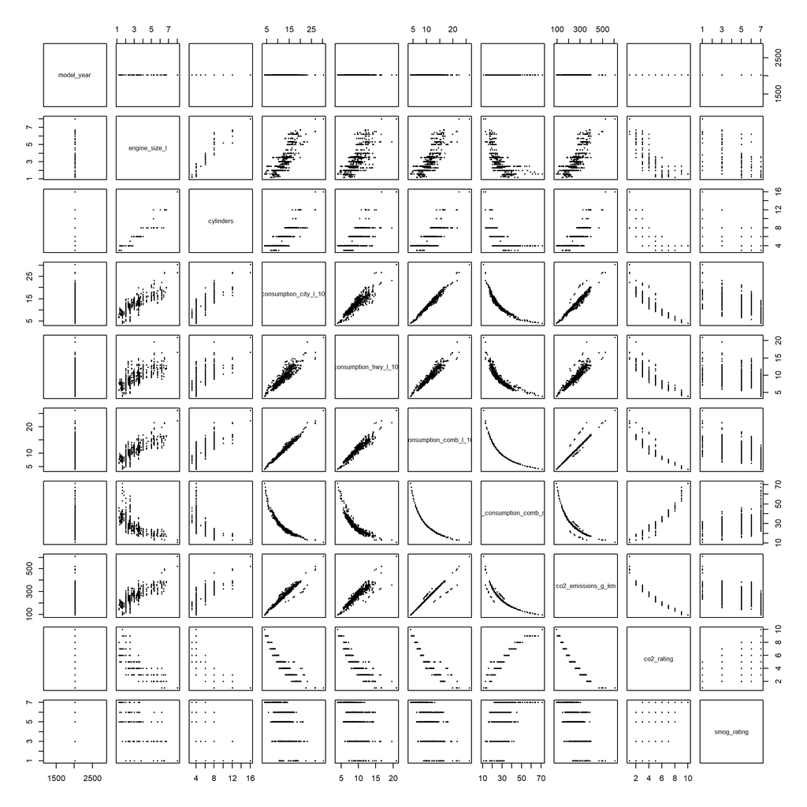

```r
num_df <- Filter(is.numeric, df)
plot(num_df, pch = 20, cex = 0.5)
```

Põhilised tähelepanekud:

## 3.2 Kategooriliste tunnuste ülevaade

### 3.2.1 Kütusetüüp (fuel_type)

Kütusetüübi koodide selgitus:

- **D** - diiselkütus
- **E** - etanool (E85: 85% etanooli ja 15% bensiini)
- **X** - tavaline bensiin (regular gasoline, oktaaniarv 87)
- **Z** - premium bensiin (premium gasoline, oktaaniarv 91 ja rohkem)

```r
tab_ft <- table(df$fuel_type)
tab_ft
```

```
##
##   D   E   X   Z
##  28  14 446 458
```

```r
prop.table(tab_ft)
```

```
##
##          D          E          X          Z
## 0.02959831 0.01479915 0.47145877 0.48414376
```

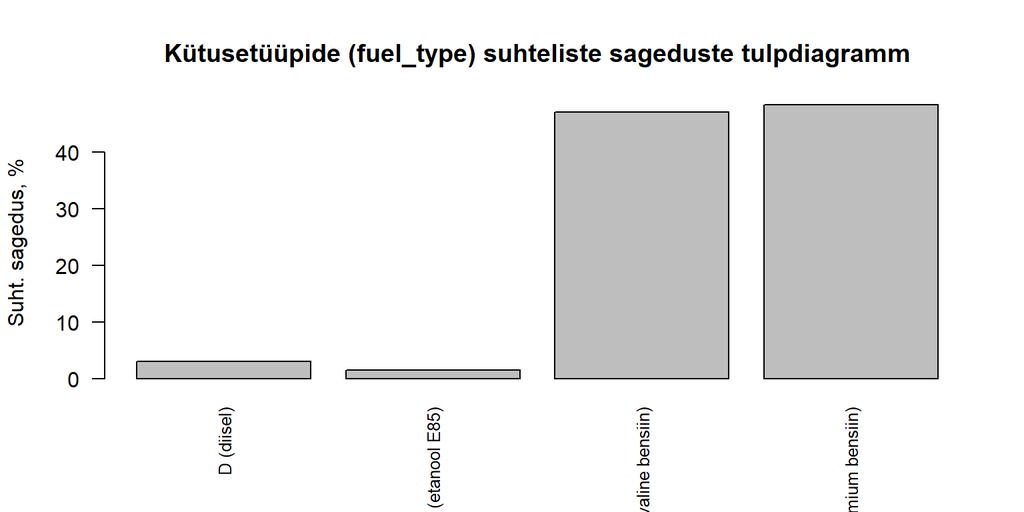

```r
nimed_ft <- c("D (diisel)", "E (etanool E85)", "X (tavaline bensiin)", "Z (premium bensiin)")
barplot(
  prop.table(tab_ft) * 100,
  names.arg = nimed_ft,
  ylab      = "Suht. sagedus, %",
  main      = "Kütusetüüpide (fuel_type) suhteliste sageduste tulpdiagramm",
  las       = 2,
  cex.names = 0.8
)
```

Suurem osa andmestiku sõidukitest kasutab bensiini - tavaline bensiin (X) ja premium bensiin (Z) moodustavad koos üle 90% vaatlustest. Diisel (D) ja etanool (E) on selgelt väiksemad grupid. Etanooli (E, n=14) puhul tuleb arvestada, et väike valim annab vähem usaldusväärseid tulemusi.

### 3.2.2 Sõidukiklass (vehicle_class)

Sõidukiklass iseloomustab sõiduki tüüpi ja suurust. See on üks peamisi CO2 heidet mõjutavaid tegureid, kuna suuremad ja raskemad sõidukid kulutavad tavaliselt rohkem kütust.

```r
tab_vc <- sort(table(df$vehicle_class), decreasing = TRUE)
tab_vc
```

```
##
##              SUV: Small           SUV: Standard                Mid-size
##                     197                     141                     117
##  Pickup truck: Standard              Subcompact                 Compact
##                     113                      80                      69
##               Full-size              Two-seater             Minicompact
##                      64                      51                      48
##     Pickup truck: Small    Station wagon: Small Special purpose vehicle
##                      20                      19                      12
## Station wagon: Mid-size                 Minivan
##                       8                       7
```

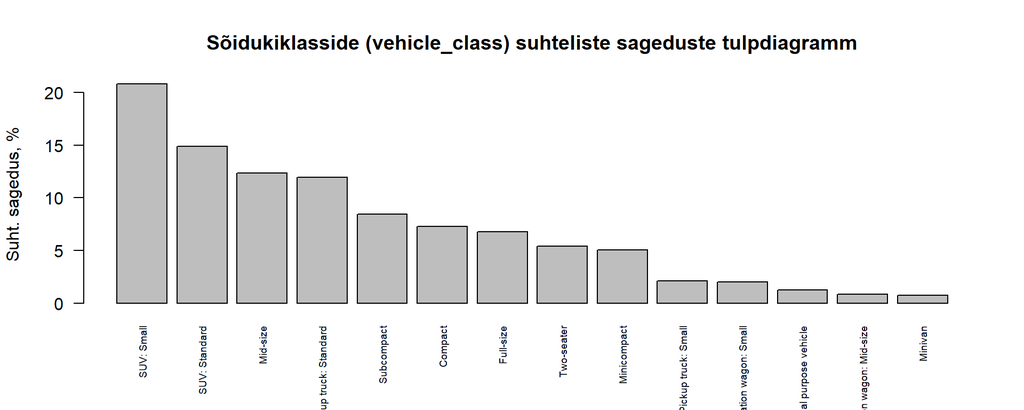

```r
barplot(
  prop.table(tab_vc) * 100,
  ylab      = "Suht. sagedus, %",
  main      = "Sõidukiklasside (vehicle_class) suhteliste sageduste tulpdiagramm",
  las       = 2,
  cex.names = 0.6
)
```

Andmestikus on kõige rohkem SUV-e (väike ja standard) ning keskmise suurusega sõiduautosid. Pikapid on samuti hästi esindatud. Minivänid (n=7) ja keskmise suurusega universaalid (Station wagon: Mid-size, n=8) on kõige väiksema valimiga klassid.

### 3.2.3 Käigukast (transmission)

Käigukasti tüüp ja käikude arv võivad mõjutada kütusekulu.

| Kood | Tüüp | Selgitus |
| --- | --- | --- |
| A | Automaatkäigukast | Käigud vahetuvad automaatselt |
| AM | Robotiseeritud käsikäigukast | Käsikäigukast automaatse siduri ja käiguvahetusega |
| AS | Automaatkäigukast käsijuhtimisega | Automaatkäigukast, mida saab ka käsitsi juhtida |
| AV | CVT (pidevalt muutuv ülekanne) | Käike ei ole, ülekandearv muutub pidevalt |
| M | Käsikäigukast | Juht vahetab käike ise |

Arv koodi järel = käikude arv (nt A8 = 8-käiguline automaat; M6 = 6-käiguline käsikäigukast; AV-l käike ei ole).

```r
tab_tr <- sort(table(df$transmission), decreasing = TRUE)
tab_tr
```

```
##
##  AS8   A8 AS10  A10   M6  AM7   A9  AM8   AV  AS6   A6  AV8  AS9   M7  AM6  AV7
##  212  100   87   72   71   70   65   52   43   39   24   23   19   14   10   10
## AV10  AV6  AS7   M5  AV1  AS5   A7
##    8    8    7    5    4    2    1
```

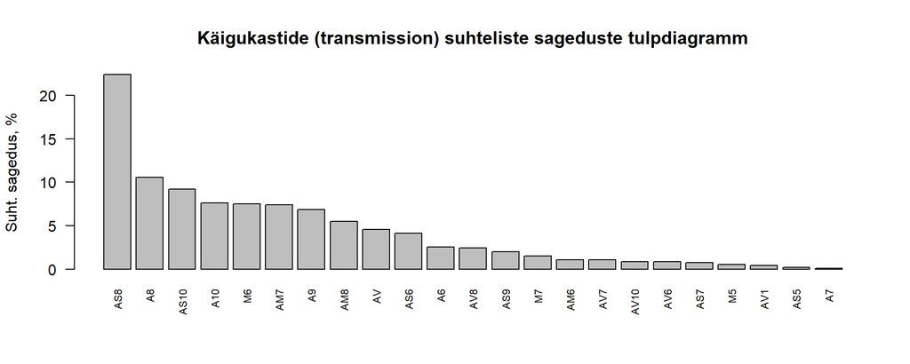

```r
barplot(
  prop.table(tab_tr) * 100,
  ylab      = "Suht. sagedus, %",
  main      = "Käigukastide (transmission) suhteliste sageduste tulpdiagramm",
  las       = 2,
  cex.names = 0.7
)
```

## 3.3 Sihttunnuse co2_emissions_g_km analüüs

CO2 heide (g/km) näitab, mitu grammi CO2 sõiduk kilomeetri jooksul õhku heidab. Mida madalam väärtus, seda keskkonnasõbralikum sõiduk.

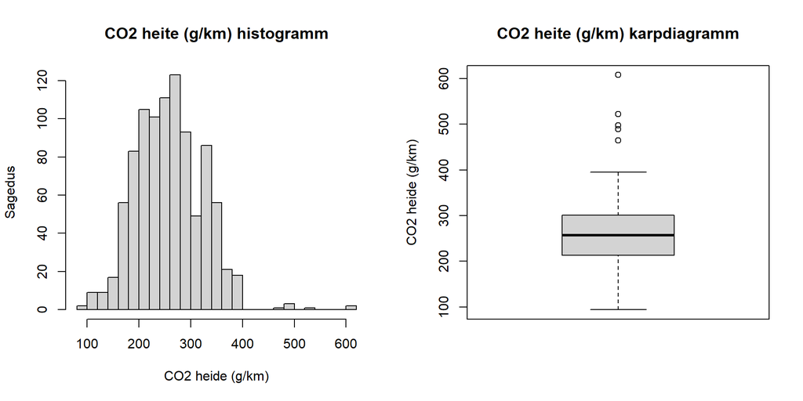

```r
par(mfrow = c(1, 2))

hist(df$co2_emissions_g_km, breaks = 30,
     main = "CO2 heite (g/km) histogramm",
     xlab = "CO2 heide (g/km)",
     ylab = "Sagedus")

boxplot(df$co2_emissions_g_km,
        main = "CO2 heite (g/km) karpdiagramm",
        ylab = "CO2 heide (g/km)")
```

```r
par(mfrow = c(1, 1))
```

```r
summary(df$co2_emissions_g_km)
```

```
##    Min. 1st Qu.  Median    Mean 3rd Qu.    Max.
##    94.0   213.2   257.0   259.2   300.8   608.0
```

```r
cat("Standardhälve:", round(sd(df$co2_emissions_g_km), 2), "\n")
```

```
## Standardhälve: 64.44
```

CO2 heite mediaan on **257 g/km** ja keskmine **259.2 g/km**. Keskmine on mediaanist kõrgem, mis tähendab, et jaotus on paremale kaldu - enamik sõidukeid jääb vahemikku 200-350 g/km, aga üksikud kõrge heitega erindid (tõenäoliselt spordi- ja luksussõidukid) tõmbavad keskmist ülespoole.

# 4 Seoste analüüs

## 4.1 Arvuliste tunnuste vahelised seosed

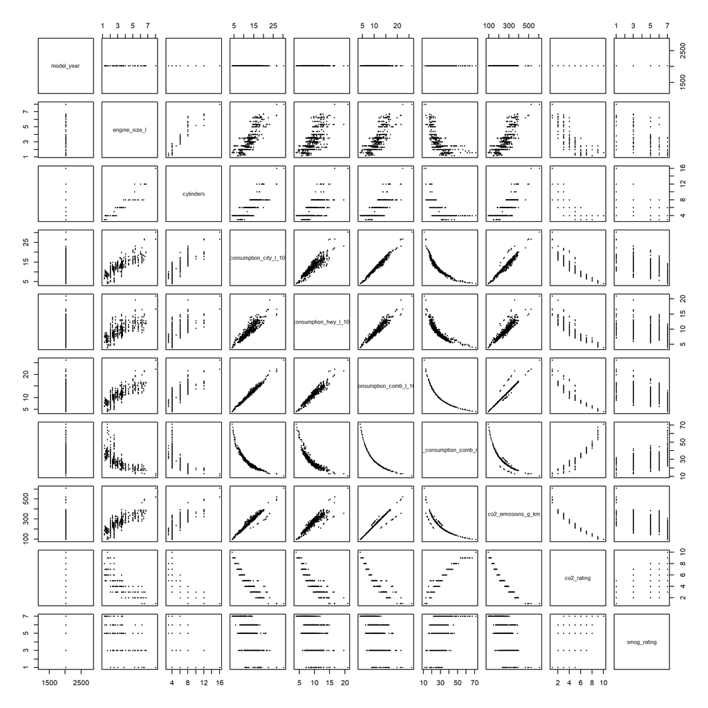

```r
num_df <- Filter(is.numeric, df)
plot(num_df, pch = 20, cex = 0.5)
```

Peamised järeldused:

- Kütusekulu L/100 km (linn, maantee, kombineeritud) on CO2 heite tugevaim ennustaja - seos on selgelt lineaarne.
- Kütusekulu linnasõidul on kõrgem kui maanteel, kuna linnas on rohkem pidurdamisi ja kiirendusi.
- **fuel_consumption_comb_mpg** näitab pöördvõrdelist seost - see on matemaatiliselt paratamatu, kuna suurem mpg tähendab väiksemat kütusekulu. Kasutame L/100 km; mpg on ainult viitena.
- Mootori maht ja silindrite arv on positiivses seoses CO2 heite ja kütusekulu näitajatega.
- model_year ei näita seost, kuna kõik vaatlused on 2022. aastast.

## 4.2 Sihttunnuse seos kategooriliste tunnustega

Kastdiagrammid näitavad CO2 heite jaotust iga kategooria kaupa.

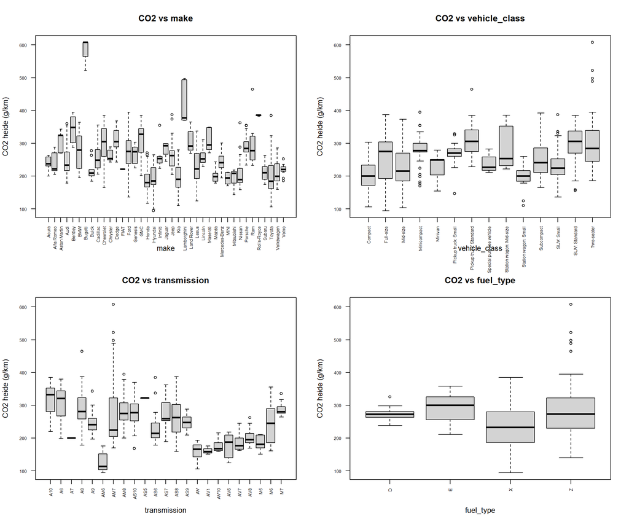

```r
CharVar <- names(df)[!sapply(df, is.numeric)]
CharVar <- CharVar[CharVar != "model"]  # model on välja jäetud - liiga palju unikaalseid väärtusi

par(mfrow = c(2, 2))
for(i in 1:min(length(CharVar), 4)){
  boxplot(df$co2_emissions_g_km ~ df[[CharVar[i]]],
          xlab     = CharVar[i],
          ylab     = "CO2 heide (g/km)",
          las      = 2,
          cex.axis = 0.6,
          main     = paste("CO2 vs", CharVar[i]))
}
```

```r
par(mfrow = c(1, 1))
```

# 5 Tööülesannete lahendamine

## 5.1 Ülesanne 1 – Maksim Ljubimov: ANOVA

**Hüpotees H1:** CO2 heide erineb statistiliselt oluliselt erinevate sõidukiklasside vahel.

- **H0:** Kõigi sõidukiklasside CO2 heite keskväärtused on võrdsed.
- **H1:** Vähemalt ühe sõidukiklassi CO2 heite keskväärtus erineb ülejäänutest (α = 0,05).

ANOVA (dispersioonanalüüs) testib, kas kolme või enama rühma keskväärtused on võrdsed. Erinevalt t-testist, mis võrdleb kahte rühma, sobib ANOVA kõigi sõidukiklasside korraga võrdlemiseks.

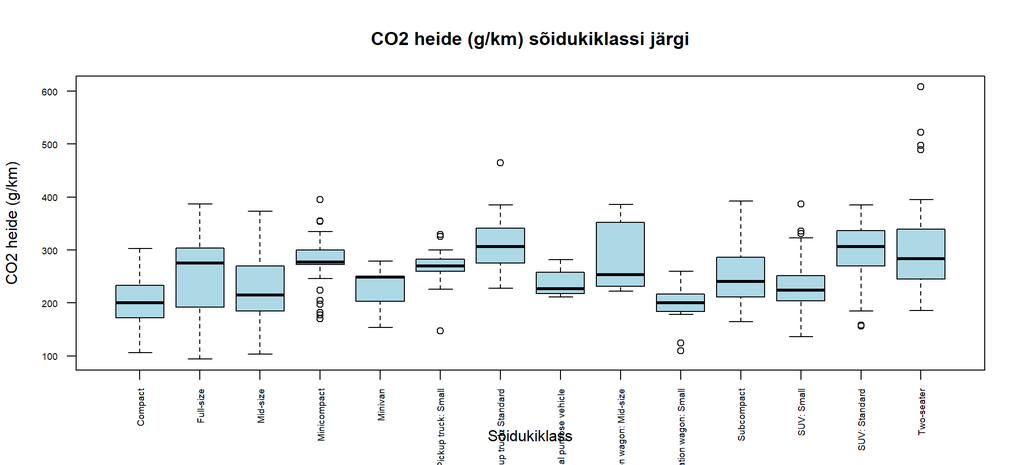

```r
boxplot(co2_emissions_g_km ~ vehicle_class, data = df,
        main     = "CO2 heide (g/km) sõidukiklassi järgi",
        xlab     = "Sõidukiklass",
        ylab     = "CO2 heide (g/km)",
        las      = 2,
        cex.axis = 0.6,
        col      = "lightblue")
```

Kastdiagrammilt on näha, et pikapid (Pickup truck) ja suuremad SUV-id on selgelt kõrgema CO2 mediaanega võrreldes kompaktautode ja väikeautodega. Minivan (n=7) ja Station wagon: Mid-size (n=8) on väikese valimiga klassid, millega seotud tulemused on vähem usaldusväärsed.

```r
model_aov <- aov(co2_emissions_g_km ~ vehicle_class, data = df)
summary(model_aov)
```

```
##                Df  Sum Sq Mean Sq F value Pr(>F)
## vehicle_class  13 1263923   97225   34.06 <2e-16 ***
## Residuals     932 2660586    2855
## ---
## Signif. codes:  0 '***' 0.001 '**' 0.01 '*' 0.05 '.' 0.1 ' ' 1
```

ANOVA väljundis vaatame F-statistikut ja p-väärtust (Pr(>F)). Kui p < 0,05, siis vähemalt kahe sõidukiklassi keskväärtused erinevad statistiliselt oluliselt.

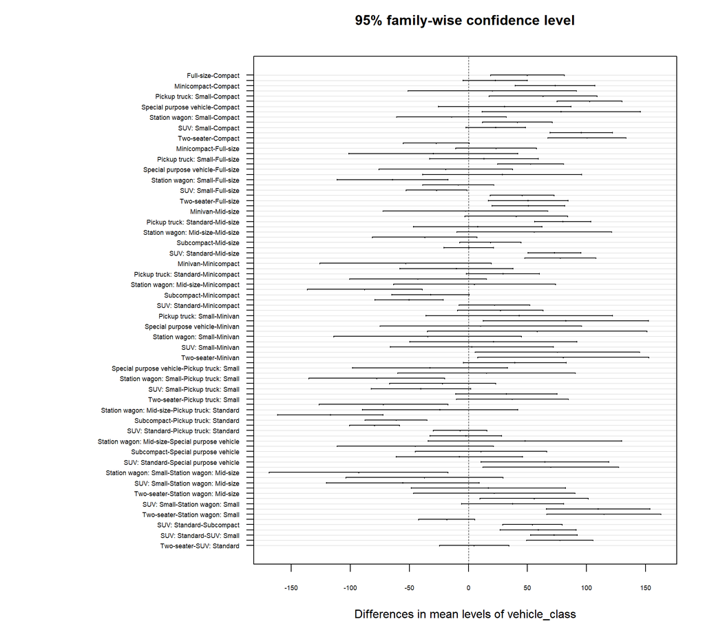

```r
tukey <- TukeyHSD(model_aov)
par(mar = c(5, 18, 4, 2))
plot(tukey, las = 1, cex.axis = 0.55)
```

Tukey HSD post-hoc test näitab, millised konkreetsed klassipaarid üksteisest statistiliselt oluliselt erinevad. Graafikul tähistab nulljoont (0) mitte lõikuv usaldusintervall statistiliselt olulist erinevust.

Kui p < 0,05, **lükatakse nullhüpotees tagasi** - CO2 heide erineb oluliselt vähemalt kahe sõidukiklassi vahel.

## 5.2 Ülesanne 2 – Pavel Sarapov: t-test

**Hüpotees H2:** Premium bensiini (Z, oktaaniarv 91+) ja tavalise bensiini (X, oktaaniarv 87) kasutajate CO2 heite keskväärtused on erinevad.

- **H0:** μ(Z) = μ(X) - keskväärtused on võrdsed.
- **H1:** μ(Z) ≠ μ(X) - keskväärtused on erinevad (kahepoolne test, α = 0,05).

t-test võrdleb kahe sõltumatu rühma keskväärtusi. Kasutame **Welchi t-testi** (var.equal = FALSE), mis ei eelda rühmade dispersioonide võrdsust. Kuna mõlemad valimid on suured (n > 30), on Keskse Piirväärtuse Teoreemi põhjal keskväärtuse normaaljaotus piisavalt tagatud.

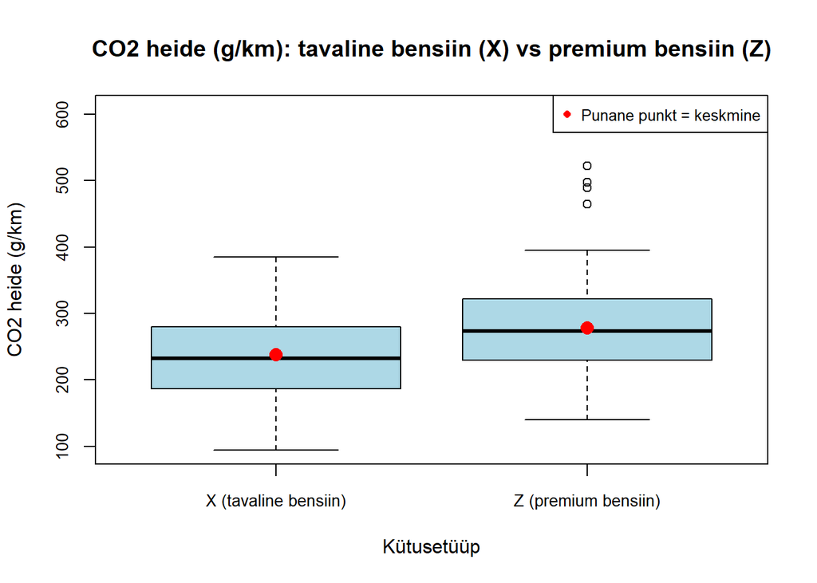

```r
df_ttest <- droplevels(subset(df, fuel_type %in% c("X", "Z")))

boxplot(co2_emissions_g_km ~ fuel_type, data = df_ttest,
        main     = "CO2 heide (g/km): tavaline bensiin (X) vs premium bensiin (Z)",
        xlab     = "Kütusetüüp",
        ylab     = "CO2 heide (g/km)",
        names    = c("X (tavaline bensiin)", "Z (premium bensiin)"),
        col      = "lightblue",
        cex.axis = 0.85)
points(seq_len(2),
       tapply(df_ttest$co2_emissions_g_km, df_ttest$fuel_type, mean),
       col = "red", pch = 16, cex = 1.5)
legend("topright", legend = "Punane punkt = keskmine", pch = 16, col = "red", cex = 0.8)
```

```r
aggregate(co2_emissions_g_km ~ fuel_type, data = df_ttest,
          FUN = function(x) round(c(
            n      = length(x),
            mean   = mean(x),
            sd     = sd(x),
            median = median(x)
          ), 2))
```

```
##   fuel_type co2_emissions_g_km.n co2_emissions_g_km.mean co2_emissions_g_km.sd
## 1         X               446.00                  237.58                 62.26
## 2         Z               458.00                  278.35                 62.13
##   co2_emissions_g_km.median
## 1                    232.00
## 2                    273.50
```

Kirjeldav statistika näitab mõlema rühma suurust (n), keskväärtust, standardhälvet ja mediaani. Kui keskväärtused visuaalselt erinevad, kontrollib t-test, kas see erinevus on statistiliselt oluline või juhuslik.

```r
t.test(co2_emissions_g_km ~ fuel_type, data = df_ttest, var.equal = FALSE)
```

```
##
##  Welch Two Sample t-test
##
## data:  co2_emissions_g_km by fuel_type
## t = -9.8535, df = 901.25, p-value < 2.2e-16
## alternative hypothesis: true difference in means between group X and group Z is not equal to 0
## 95 percent confidence interval:
##  -48.88886 -32.64839
## sample estimates:
## mean in group X mean in group Z
##        237.5807        278.3493
```

Welchi t-testi väljundis vaatame p-väärtust ja 95% usaldusintervalli keskväärtuste vahele.

Kui p < 0,05, **lükatakse nullhüpotees tagasi** - premium bensiin (Z, oktaaniarv 91+) ja tavaline bensiin (X, oktaaniarv 87) kasutajate sõidukite CO2 heite keskväärtused erinevad statistiliselt oluliselt.

## 5.3 Ülesanne 3 – Maksim Lupanov: Regressioonanalüüs

**Hüpotees H3:** CO2 heidet on võimalik ennustada mootori mahu (`engine_size_l`, liitrites) ja silindrite arvu (`cylinders`) põhjal lineaarse regressiooni abil.

- **H0:** β1 = β2 = 0 - kumbki prediktor ei mõjuta CO2 heidet.
- **H1:** Vähemalt üks regressioonikoefitsient erineb nullist (α = 0,05).

Lineaarne regressioon modelleerib sihttunnuse lineaarset sõltuvust prediktortest. Mudeli kuju: CO2 = β0 + β1 × engine_size + β2 × cylinders + viga. R² näitab, kui suure osa CO2 heite varieeruvusest mudel seletab (vahemikus 0 kuni 1, kus 1 = täiuslik ennustus).

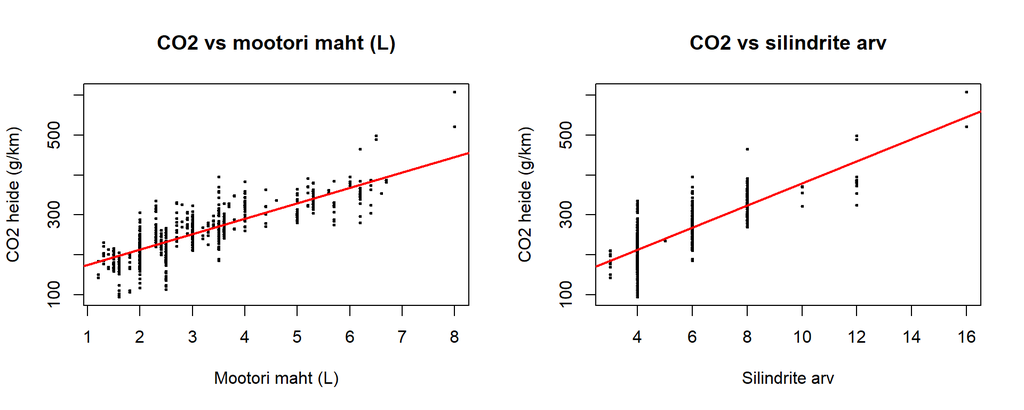

```r
par(mfrow = c(1, 2))

plot(df$engine_size_l, df$co2_emissions_g_km,
     pch  = 20, cex = 0.5,
     xlab = "Mootori maht (L)",
     ylab = "CO2 heide (g/km)",
     main = "CO2 vs mootori maht (L)")
abline(lm(co2_emissions_g_km ~ engine_size_l, data = df), col = "red", lwd = 2)

plot(df$cylinders, df$co2_emissions_g_km,
     pch  = 20, cex = 0.5,
     xlab = "Silindrite arv",
     ylab = "CO2 heide (g/km)",
     main = "CO2 vs silindrite arv")
abline(lm(co2_emissions_g_km ~ cylinders, data = df), col = "red", lwd = 2)
```

```r
par(mfrow = c(1, 1))
```

Mõlema prediktori ja CO2 heite vahel on näha positiivne seos - suurem mootor ja rohkem silindrid tähendavad kõrgemat CO2 heidet. Punane joon on lihtne lineaarne regressioonijoon.

```r
model_lm <- lm(co2_emissions_g_km ~ engine_size_l + cylinders, data = df)
summary(model_lm)
```

```
##
## Call:
## lm(formula = co2_emissions_g_km ~ engine_size_l + cylinders,
##     data = df)
##
## Residuals:
##      Min       1Q   Median       3Q      Max
## -109.943  -21.963    1.908   19.876  125.134
##
## Coefficients:
##               Estimate Std. Error t value Pr(>|t|)
## (Intercept)    110.704      3.629  30.506   <2e-16 ***
## engine_size_l   17.549      2.086   8.414   <2e-16 ***
## cylinders       16.290      1.484  10.980   <2e-16 ***
## ---
## Signif. codes:  0 '***' 0.001 '**' 0.01 '*' 0.05 '.' 0.1 ' ' 1
##
## Residual standard error: 34.4 on 943 degrees of freedom
## Multiple R-squared:  0.7156, Adjusted R-squared:  0.715
## F-statistic:  1187 on 2 and 943 DF,  p-value: < 2.2e-16
```

Mudeli väljundist vaatame:

- **Estimate (koefitsiendid):** Mitu g/km suureneb CO2 heide, kui prediktor suureneb ühe ühiku võrra (mootori maht 1 liitri või silindrite arv 1 silindri võrra), hoides teise prediktori muutumatuks.
- **p-väärtused:** Kas iga prediktor on mudeli jaoks oluline (p < 0,05).
- **R² (Multiple R-squared):** Kui suur osa CO2 heite varieeruvusest on seletatav mootori mahu ja silindrite arvuga.
- **F-statistik:** Mudeli üldine olulisus.

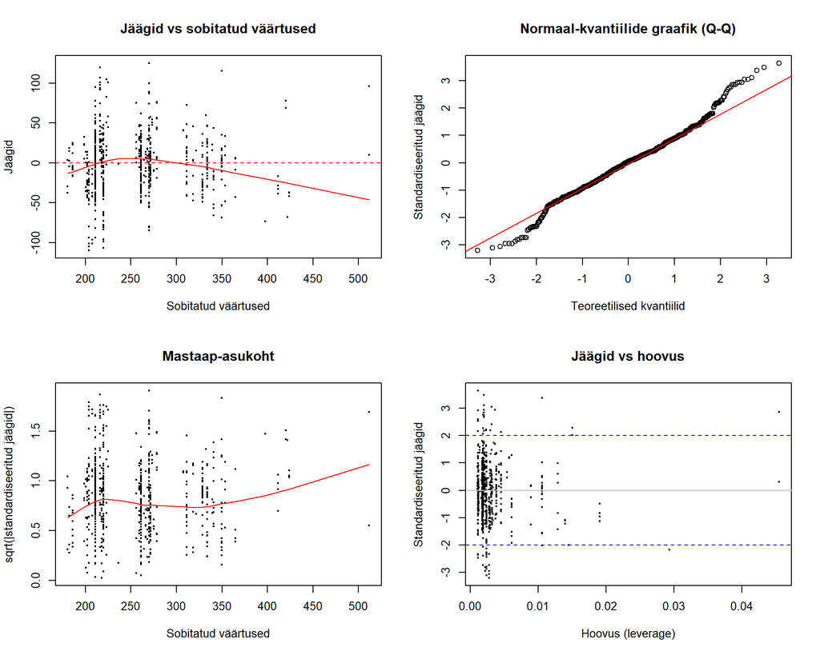

```r
par(mfrow = c(2, 2))

# 1. Jäägid vs sobitatud väärtused
plot(fitted(model_lm), residuals(model_lm),
     main = "Jäägid vs sobitatud väärtused",
     xlab = "Sobitatud väärtused",
     ylab = "Jäägid",
     pch = 20, cex = 0.5)
abline(h = 0, col = "red", lty = 2)
lines(lowess(fitted(model_lm), residuals(model_lm)), col = "red")

# 2. Normaal-kvantiilide graafik
qqnorm(rstandard(model_lm),
       main = "Normaal-kvantiilide graafik (Q-Q)",
       xlab = "Teoreetilised kvantiilid",
       ylab = "Standardiseeritud jäägid")
qqline(rstandard(model_lm), col = "red")

# 3. Mastaap-asukoha graafik
plot(fitted(model_lm), sqrt(abs(rstandard(model_lm))),
     main = "Mastaap-asukoht",
     xlab = "Sobitatud väärtused",
     ylab = "sqrt(|standardiseeritud jäägid|)",
     pch = 20, cex = 0.5)
lines(lowess(fitted(model_lm), sqrt(abs(rstandard(model_lm)))), col = "red")

# 4. Jäägid vs hoovus
plot(hatvalues(model_lm), rstandard(model_lm),
     main = "Jäägid vs hoovus",
     xlab = "Hoovus (leverage)",
     ylab = "Standardiseeritud jäägid",
     pch = 20, cex = 0.5)
abline(h = c(-2, 0, 2), lty = c(2, 1, 2), col = c("blue", "gray", "blue"))
```

```r
par(mfrow = c(1, 1))
```

Diagnostikagraafikud kontrollivad mudeli eeldusi: **Jäägid vs sobitatud väärtused** näitab, kas jäägid on juhuslikud (ei tohiks olla selget mustrit); **Normaal-kvantiilide graafik (Q-Q)** kontrollib jääkide normaaljaotust (punktid peaksid järgima punast sirget); **Mastaap-asukoht** näitab, kas hajuvus on ühtlane; **Jäägid vs hoovus** tuvastab mõjukad erindid, mis mudeli tulemust tugevalt mõjutavad.

Kui F-testi p < 0,05, **lükatakse nullhüpotees tagasi** - mudel on statistiliselt oluline.

## 5.4 Ülesanne 4 – Samuil Batsinski: Hii-ruut test

**Hüpotees H4:** Kütusetüüp (`fuel_type`) ja sõidukiklass (`vehicle_class`) ei ole sõltumatud - need tunnused on omavahel seotud.

- **H0:** Kütusetüüp ja sõidukiklass on sõltumatud tunnused.
- **H1:** Kütusetüüp ja sõidukiklass on omavahel seotud (α = 0,05).

Hii-ruut sõltumatuse test kontrollib, kas kahe kategoorilise tunnuse jaotused sõltuvad teineteisest. Kui sõidukiklass ei mõjutaks kütusetüüpi, peaks kütusetüüpide jaotus olema kõikides klassides ligikaudu sama. Seos tähendaks, et teatud klassides (nt pikapid) kasutatakse rohkem teatud kütust (nt diisel).

```r
tab_chi <- table(df$fuel_type, df$vehicle_class)
tab_chi
```

```
##
##     Compact Full-size Mid-size Minicompact Minivan Pickup truck: Small
##   D       0         0        0           0       0                   5
##   E       0         0        0           0       0                   0
##   X      31        27       50           0       7                  15
##   Z      38        37       67          48       0                   0
##
##     Pickup truck: Standard Special purpose vehicle Station wagon: Mid-size
##   D                     12                       0                       0
##   E                     12                       2                       0
##   X                     78                       7                       1
##   Z                     11                       3                       7
##
##     Station wagon: Small Subcompact SUV: Small SUV: Standard Two-seater
##   D                    0          0          2             9          0
##   E                    0          0          0             0          0
##   X                   12         21        145            51          1
##   Z                    7         59         50            81         50
```

Sagedustabel näitab iga kütusetüübi ja sõidukiklassi kombinatsiooni vaatluste arvu. Paljud lahtrid on nullid - teatud klassides ei kasutata teatud kütust üldse.

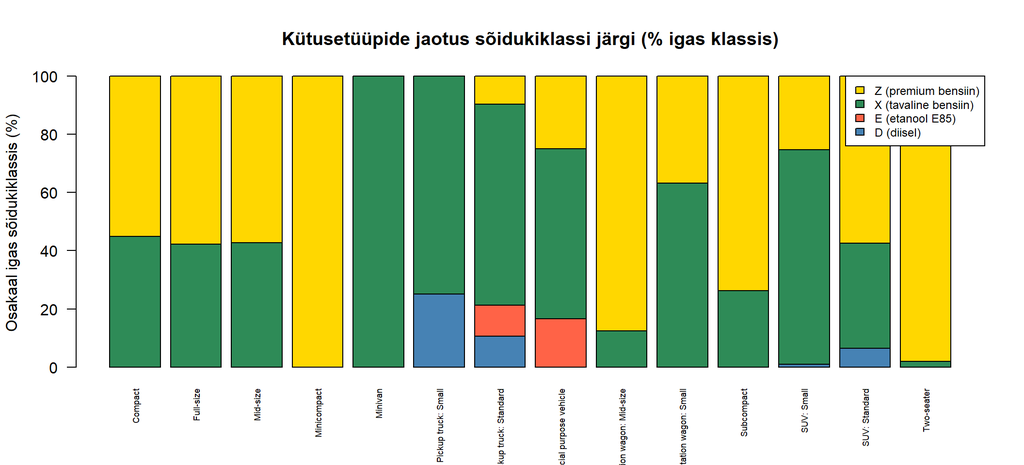

```r
tab_prop <- prop.table(tab_chi, margin = 2) * 100

nimed_legend <- c("D (diisel)", "E (etanool E85)", "X (tavaline bensiin)", "Z (premium bensiin)")

barplot(
  tab_prop,
  beside      = FALSE,
  las         = 2,
  cex.names   = 0.55,
  col         = c("steelblue", "tomato", "seagreen", "gold"),
  legend.text = nimed_legend,
  args.legend = list(x = "topright", cex = 0.75, bg = "white"),
  main = "Kütusetüüpide jaotus sõidukiklassi järgi (% igas klassis)",
  ylab = "Osakaal igas sõidukiklassis (%)"
)
```

Tulpdiagramm näitab kütusetüüpide osakaalu igas sõidukiklassis. Kui jaotus oleks kõikides klassides sama, tähendaks see, et tunnused on sõltumatud. Silmaga nähtavad erinevused (nt sinine diisel (D) erineva osakaaluga eri klassides) viitavad võimalikule seosele.

```r
chi_test <- chisq.test(tab_chi)
chi_test
```

```
##
##  Pearson's Chi-squared test
##
## data:  tab_chi
## X-squared = 423.17, df = 39, p-value < 2.2e-16
```

Kontrollin hii-ruut testi põhinõuet - oodatavad sagedused igas lahtris peavad olema vähemalt 5. Väiksemad oodatavad sagedused muudavad testi tulemuse ebausaldusväärseks.

```r
cat("Minimaalne oodatav sagedus:", round(min(chi_test$expected), 2), "\n")
```

```
## Minimaalne oodatav sagedus: 0.1
```

```r
cat("Lahtreid oodatava sagedusega < 5:", sum(chi_test$expected < 5), "\n")
```

```
## Lahtreid oodatava sagedusega < 5: 31
```

Kui p < 0,05, **lükatakse nullhüpotees tagasi** - kütusetüüp (D=diisel, E=etanool, X=tavaline bensiin, Z=premium bensiin) ja sõidukiklass on statistiliselt oluliselt seotud ehk kütusetüübi valik sõltub sõidukiklassist.

# 6 Kokkuvõte

Selles projektis analüüsisime 2022. aasta Kanada turu sõidukite CO2 heidet (g/km) **946 sõiduki** andmete põhjal, kasutades nelja erinevat statistilist meetodit.

**Hüpoteeside tulemuste kokkuvõte:**

| # | Hüpotees | Meetod | Vastutaja | Otsus |
| --- | --- | --- | --- | --- |
| H1 | CO2 heide erineb sõidukiklasside vahel | ANOVA | M. Ljubimov | H0 lükatakse tagasi — CO2 heide erineb oluliselt klasside vahel (pikapid ja SUV-id kõrgemad kui kompaktautod). |
| H2 | Premium (Z) ja tavaline bensiin (X) erinevad CO2 poolest | t-test | P. Sarapov | H0 lükatakse tagasi — premium bensiini kasutavate sõidukite CO2 heide on oluliselt kõrgem. |
| H3 | CO2 ennustatav mootori mahu ja silindrite arvu põhjal | Regressioon | M. Lupanov | H0 lükatakse tagasi — mõlemad prediktorid on olulised (p < 0,05), suurem mootor = suurem heide. |
| H4 | Kütusetüüp ja sõidukiklass ei ole sõltumatud | Hii-ruut | S. Batsinski | H0 lükatakse tagasi — kütusetüübi jaotus erineb oluliselt sõidukiklasside vahel. |

Analüüsi põhjal selgus, et CO2 heidet mõjutavad oluliselt nii sõiduki tehnilised omadused (mootori maht, silindrite arv) kui ka kategoorilised tunnused (kütusetüüp, sõidukiklass). Tulemused ühtivad eelnevate seminaritööde järeldustega.

# 7 Kasutatud materjalid

1. Natural Resources Canada (2022). *2022 Fuel Consumption Ratings*. https://www.kaggle.com/datasets/rinichristy/2022-fuel-consumption-ratings

# 8 Lisa